# CIFAR10 Image Classification

### 0. Dataset

**SOURCE: https://www.cs.toronto.edu/~kriz/cifar.html**

The CIFAR-10 dataset consists of 60000 32x32 colour images in 10 classes, with 6000 images per class. There are 50000 training images and 10000 test images.

The dataset is divided into five training batches and one test batch, each with 10000 images. The test batch contains exactly 1000 randomly-selected images from each class. The training batches contain the remaining images in random order, but some training batches may contain more images from one class than another. Between them, the training batches contain exactly 5000 images from each class.

[figure not shown]

### 1. Implementation

A CNN architecture that consists of 3 convolutional layers followed by a hidden fully connected layer of 1000 units.

Each convolutional layer consists of a sublayer of 5x5 convolutional filters with stride 1 followed by a sublayer of 2x2 max-pool units with stride 2. Each neuron applies ReLU activation function.

The hyper-parameter settings hereby:

minibatch size = 128

learning rate = 0.001

total number of epoches = 100

```
Without Dropout

Start GD
Epoch: 20, Loss: 123.7840
Epoch: 40, Loss: 88.2728
Epoch: 60, Loss: 54.1098
Epoch: 80, Loss: 29.1642
Epoch: 100, Loss: 17.8444
GD accuracy: 0.674500

Start AdaGrad
Epoch: 20, Loss: 143.1605
Epoch: 40, Loss: 128.1978
Epoch: 60, Loss: 120.6127
Epoch: 80, Loss: 114.5898
Epoch: 100, Loss: 109.9403
AdaGrad accuracy: 0.600900

Start Nesterov
Epoch: 20, Loss: 108.1790
Epoch: 40, Loss: 64.8852
Epoch: 60, Loss: 38.8450
Epoch: 80, Loss: 25.0962
Epoch: 100, Loss: 24.1882
Nesterov accuracy: 0.643100

Start Adam
Epoch: 20, Loss: 75.3612
Epoch: 40, Loss: 41.9441
Epoch: 60, Loss: 20.9182
Epoch: 80, Loss: 10.7441
Epoch: 100, Loss: 7.9088
Adam accuracy: 0.732400


With Dropout

Start GD
Epoch: 20, Loss: 157.7647
Epoch: 40, Loss: 132.1380
```

[output cut: 13 more lines]

```
Start Nesterov
Epoch: 20, Loss: 139.7887
Epoch: 40, Loss: 119.0004
Epoch: 60, Loss: 108.3263
Epoch: 80, Loss: 101.5392
Epoch: 100, Loss: 95.6965
Nesterov accuracy: 0.662400

Start Adam
Epoch: 20, Loss: 108.4746
Epoch: 40, Loss: 89.2963
Epoch: 60, Loss: 75.9780
Epoch: 80, Loss: 68.9512
Epoch: 100, Loss: 63.9750
Adam accuracy: 0.756900
```

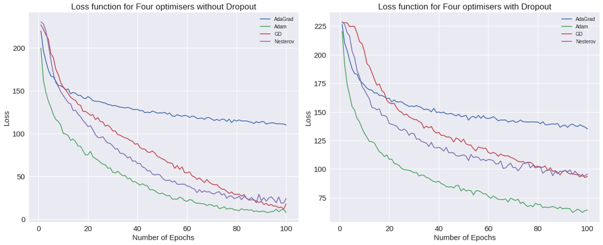

```python
"""
@author: optboy
"""

import numpy as np
import pandas as pd
import tensorflow as tf
import matplotlib.pyplot as plt
from keras.datasets import cifar10

(data_train, label_train), (data_test, label_test) = cifar10.load_data()

data_train = data_train / 255 # get float32 for conv2d and metrics
data_test = data_test / 255
label_train =np.squeeze(label_train) # squeeze the 1
label_test =np.squeeze(label_test)

tf.reset_default_graph()
tf.logging.set_verbosity(tf.logging.INFO)

def classification_cnn(data, training=False):
    with tf.variable_scope('classification_cnn', reuse=tf.AUTO_REUSE):
        # 32*32*3 for rgb
        inputs = tf.reshape(data, [-1, 32, 32, 3])
        # convolutional layer 1
        conv1 = tf.layers.conv2d(inputs=inputs, filters=32, kernel_size=[5, 5], strides=[1, 1], padding="same", activation=tf.nn.relu)
        # pooling layer
        pool1 = tf.layers.max_pooling2d(inputs=conv1, pool_size=[2, 2], strides=2) # stride 2
        dropout1 = tf.layers.dropout(inputs=pool1, rate=0.3, training=training)

        # convlutional layer 2
        conv2 = tf.layers.conv2d(inputs=dropout1, filters=64, kernel_size=[5, 5], strides=[1, 1], padding="same", activation=tf.nn.relu)
        pool2 = tf.layers.max_pooling2d(inputs=conv2, pool_size=[2, 2], strides=2)
        dropout2 = tf.layers.dropout(inputs=pool2, rate=0.3, training=training)

        # convlutional layer 2
        conv3 = tf.layers.conv2d(inputs=dropout2, filters=128, kernel_size=[5, 5], strides=[1, 1], padding="same", activation=tf.nn.relu)
        pool3 = tf.layers.max_pooling2d(inputs=conv3, pool_size=[2, 2], strides=2)
        dropout2 = tf.layers.dropout(inputs=pool3, rate=0.3, training=training)

        p2_flat = tf.reshape(dropout2, [-1, 4 * 4 * 128]) # 32 / 2 / 2 / 2

        # dense layer
        h1 = tf.layers.dense(inputs=p2_flat, units=1000, activation=tf.nn.relu)
        dropout3 = tf.layers.dropout(inputs=h1, rate=0.4, training=training)

        # output layer
        outputs = tf.layers.dense(inputs=dropout3, units=10, activation=None)

    return outputs

def build_batches(batch_size, data, labels, num_batch):
    """ input batch size, the whole data, the whole labels, and the number of batches that need
        return the batches
    """
    id_shuffle = np.arange(0 , len(data))
    np.random.shuffle(id_shuffle) # shuffle the id rather than data in order to save memory
    batches = []

    for i in range(num_batch):
        id_sample = id_shuffle[batch_size*i:batch_size*(i+1)] # get the shuffled data
        data_batch = [data[i] for i in id_sample]
        labels_batch = [labels[i] for i in id_sample]
        batches.append((np.array(data_batch), np.squeeze(np.array(labels_batch))))

    return batches

def run_cnn(optimizer_flag, training=False):
    # set params
    print('\nStart', optimizer_flag)
    batch_size = 128
    x_dim = 32
    x_channel = 3
    learning_rate = 0.001
    num_epoches = 100
    num_batches = 50

    # set scope
    with tf.variable_scope('main', reuse=tf.AUTO_REUSE):
        x = tf.placeholder(tf.float64, [batch_size, x_dim, x_dim, x_channel]) # 128 * 32 * 32 * 3
        y = tf.placeholder(tf.int64, [batch_size, ]) # 128,
        outputs = classification_cnn(x, training=training)
        loss = tf.reduce_mean(tf.nn.sparse_softmax_cross_entropy_with_logits(labels=y, logits=outputs)) * 100.0
        if optimizer_flag == "GD":
            optimiser = tf.train.GradientDescentOptimizer(learning_rate).minimize(loss)
        elif optimizer_flag == "AdaGrad":
            optimiser = tf.train.AdagradOptimizer(learning_rate).minimize(loss)
        elif optimizer_flag == "Nesterov":
            momentum = 0.7
            optimiser = tf.train.MomentumOptimizer(learning_rate, momentum).minimize(loss)
        elif optimizer_flag == "Adam":
            optimiser = tf.train.AdamOptimizer(learning_rate).minimize(loss)

        preds = classification_cnn(data_test, training=False) # predict the result
        predictions_idx = tf.argmax(tf.nn.softmax(preds), axis=1)

    with tf.Session() as sess:
        sess.run(tf.global_variables_initializer())
        sess.run(tf.local_variables_initializer()) # initial also local
        loss_list = []
        for epoch in range(1, num_epoches+1):
            batches = build_batches(batch_size, data_train, label_train, num_batches) # build batches
            loss_list_temp = []
            for batch_data, batch_labels in batches:
                _, l = sess.run([optimiser, loss], feed_dict={x: batch_data, y: batch_labels})
                loss_list_temp.append(l)
            loss_mean = np.mean(loss_list_temp) # average the loss
            loss_list.append(loss_mean)
            loss_list_temp = []
            if epoch % 20 == 0:
                print('Epoch: {}, Loss: {:.4f}'.format(epoch, loss_mean))

        accuracy = sum(predictions_idx.eval() == label_test) / len(label_test) # calculate the accuracy
        print("%s accuracy: %f"%(optimizer_flag, accuracy))

    return loss_list

def plot_data(lst1, lst2, lst3, lst4, ax, title):
    """input the different list for each optimiser, axe that use, title name of figure
    """
    df_results = pd.DataFrame({"GD": lst1, "AdaGrad": lst2, "Nesterov": lst3, "Adam": lst4})
    df_results.index = np.arange(1, len(lst1)+1)
    df_results.plot(fontsize=15, ax=ax)
    ax.set_title(title, fontsize=17)
    ax.set_xlabel("Number of Epochs", fontsize=15)
    ax.set_ylabel("Loss", fontsize=15)
    ax.legend(bbox_to_anchor=(1.001, 1));

if __name__ == "__main__":
    fig, axes = plt.subplots(ncols=2, nrows=1, figsize=(17, 7))

    print("Without Dropout")
    gd_loss_list = run_cnn("GD", training=False)
    adagrad_loss_list = run_cnn("AdaGrad", training=False)
    nesterov_loss_list = run_cnn("Nesterov", training=False)
    adams_loss_list = run_cnn("Adam", training=False)

    plot_data(gd_loss_list, adagrad_loss_list, nesterov_loss_list, adams_loss_list, axes[0], "Loss function for Four optimisers without Dropout")

    print("\n\nWith Dropout")
    gd_loss_list = run_cnn("GD", training=True)
    adagrad_loss_list = run_cnn("AdaGrad", training=True)
    nesterov_loss_list = run_cnn("Nesterov", training=True)
    adams_loss_list = run_cnn("Adam", training=True)

    plot_data(gd_loss_list, adagrad_loss_list, nesterov_loss_list, adams_loss_list, axes[1], "Loss function for Four optimisers with Dropout")

    fig.tight_layout()
```

### 2. Optimiser Comparation

[output not shown]

### 3. Result Discussion

[output not shown]